```python
%matplotlib inline
import numpy as np
import matplotlib.pyplot as plt
from sklearn.linear_model import LinearRegression
```

# Chapter 4

## Linear Regression

Linear models make predictions by computing weighted sums of input features plus a *bias term*.

$\hat{y}= \theta_0 + \theta_1x_1 + \theta_2x_2 + ... \theta_nx_n$

or in vectorized form

$\hat{y} = h_\theta(x) = \boldsymbol{\theta} \cdot \boldsymbol{x}$

in these equations $x$ are the values of features and $\theta$ are model parameters. $h_\theta$ is just simply the representation of a hypothesis function (a set of $\theta$s) To train one of these models we need to find a set of $\theta$ that minimizes the error on data. The most common performance measure on a regression model is the RMSE. So we need to find $\theta$ values to minimize the RMSE. In practice it's simpler to minimize the MSE and minimizing MSE also minimizes RMSE..

The MSE of a linear regression hypothesis $h_\theta$ on a training set $\boldsymbol{X}$ is

$MSE(\boldsymbol{X}, h_\theta) = \frac{1}{m}\sum_{i=1}^m{(\boldsymbol{\theta}^T\boldsymbol{x}^{(i)}-y^{(i)})^2}$

### The Normal Equation

To find the value of $\boldsymbol{\theta}$ that minimizes the cost function there is a close-form solution. This basically means there is an equation that gives us the result directly. It's called the *Normal Equation*

$\hat{\boldsymbol{\theta}} = (\boldsymbol{X}^T\boldsymbol{X})^{-1}\boldsymbol{X}^T\boldsymbol{y}$

Let's generate some linear looking data to test this out.

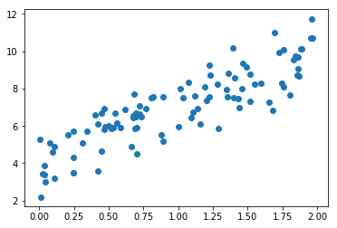

```python
X = 2 * np.random.rand(100, 1)
y = 4 + 3 * X + np.random.randn(100, 1)
plt.scatter(X, y)
plt.show()
```

Now we'll compute $\hat{\boldsymbol{\theta}}$ using the Normal Equation.

```python
X_b = np.c_[np.ones((100,1)), X]  # add x0 = 1 to each instances
theta_best = np.linalg.inv(X_b.T.dot(X_b)).dot(X_b.T).dot(y)
```

The actual function we used to generate the dat a is $y = 4+3x_1$ + Gaussian noise. And what the equation found was

```python
theta_best
```

```
array([[4.13671508],
       [2.90626417]])
```

ideally we would have found $\theta_0=4$ and $\theta_1=3$. We got pretty close but the noise make it impossible to recover the exact parameters of the original function.

We can now make predictions using these $\theta$ values.

```python
X_new = np.array([[0],[2]])
X_new_b = np.c_[np.ones((2,1)), X_new]
y_predict = X_new_b.dot(theta_best)
y_predict
```

```
array([[4.13671508],
       [9.94924342]])
```

Let's plot this models predictions.

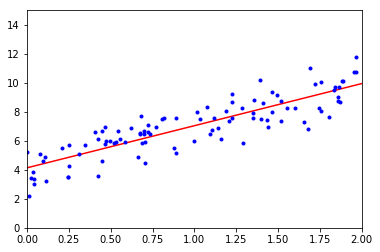

```python
plt.plot(X_new, y_predict, "r-")
plt.plot(X, y, "b.")
plt.axis([0, 2, 0, 15])
plt.show()
```

Performing linear regression with sklearn is pretty simple.

```python
lin_reg = LinearRegression()
lin_reg.fit(X, y)
lin_reg.intercept_, lin_reg.coef_
```

```
(array([4.13671508]), array([[2.90626417]]))
```

Note that `intercept_` here is the bias term and `coef_` would be the rest of the weights.

The LinearRegression class is based on the `scipy.linalg.lstsq()` function, which you could call directly.

```python
theta_best_svd, residuals, rank, s = np.linalg.lstsq(X_b, y, rcond=1e-6)
theta_best_svd
```

```
array([[4.13671508],
       [2.90626417]])
```

This function computes $\hat{\theta} = \boldsymbol{X}^+\boldsymbol{y}$ where $\boldsymbol{X}^+$ is the pseudoinverse of $\boldsymbol{X}$. This pseudoinverse is calculated by *Singular Value Decomposition* (SVD)

All this being said. The Normal Equation computers the inverse of $X^TX$ which has a computational complexity of about $O(n^2.4)$ to $O(n^3)$. The SVD approach is about $O(n^2)$

These complexities might be fine for relatively small number of training instances, but they're not great. We'll next look at a technique that is a bit better for larger numbers of instances.